# DS202 Lab 3

Muhammad Khairi Norizan

10/3/2021

## Exploration

#### Question 1

Find the average years of education for the respondents with each marital status. Arrange your output in a meaningful order and print. Describe any patterns you find.

```r
selectedDat <- dat %>%
  group_by(MaritalStatus) %>%
  summarize(AvgYearsSchoolCompleted = mean(YearsSchoolCompleted))

selectedDat <- selectedDat %>%
  arrange(desc(AvgYearsSchoolCompleted))

print(selectedDat)
```

```
## # A tibble: 6 × 2
##   MaritalStatus AvgYearsSchoolCompleted
##   <chr>                           <dbl>
## 1 No answer                        15.5
## 2 Never married                    13.4
## 3 Divorced                         13.1
## 4 Married                          13.0
## 5 Separated                        11.9
## 6 Widowed                          11.2
```

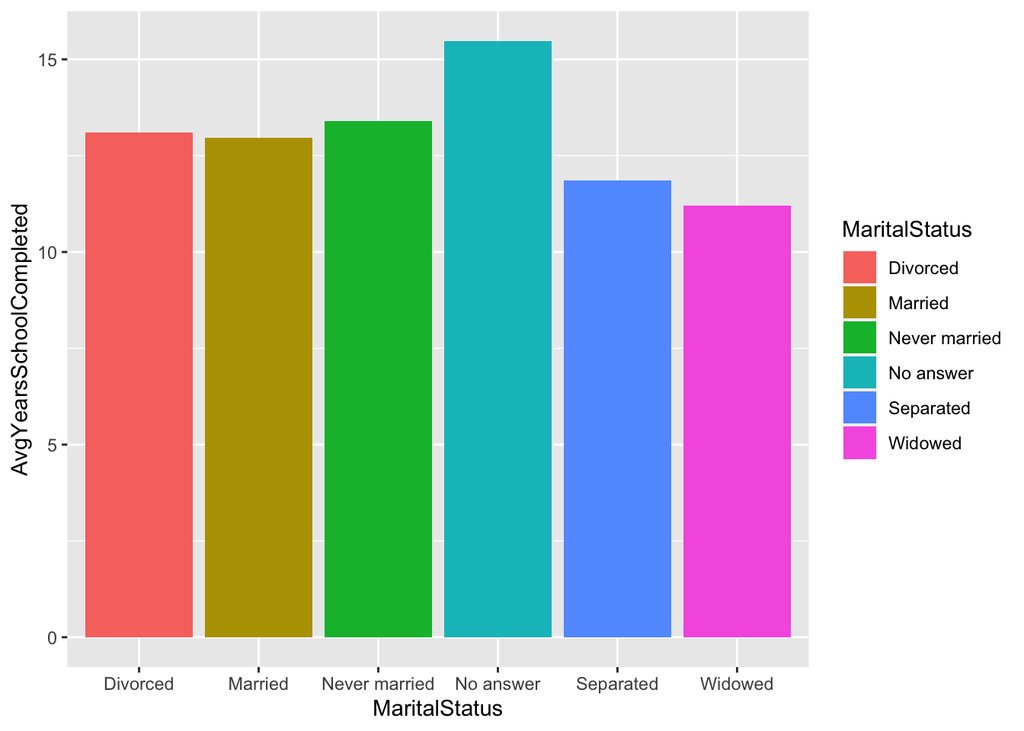

```r
ggplot(selectedDat, aes(x=MaritalStatus, y=AvgYearsSchoolCompleted, fill=MaritalStatus)) + geom_bar(stat="identity")
```

#### Question 2

Create a single data frame containing records for the better educated respondents with each marital status. A “better educated” respondent is someone who has strictly more years of education than the average among those with the same marital status. Print the structure of the data frame.

```r
betterEducatedFilter <- dat %>%
  group_by(MaritalStatus) %>%
  mutate(AvgYearsSchoolCompleted = mean(YearsSchoolCompleted, na.rm = TRUE)) %>%
  filter(YearsSchoolCompleted >= AvgYearsSchoolCompleted)

print(str(betterEducatedFilter))
```

```
## grouped_df [30,714 × 11] (S3: grouped_df/tbl_df/tbl/data.frame)
##  $ Year                   : num [1:30714] 1972 1972 1972 1972 1972 ...
##  $ Happiness              : chr [1:30714] "Not too happy" "Not too happy" "Pretty happy" "Not too happy" ...
##  $ Politics               : chr [1:30714] "Ind,near dem" "Not str democrat" "Ind,near dem" "Ind,near dem" ...
##  $ FamilyIncome           : chr [1:30714] "Not applicable" "Not applicable" "Not applicable" "Not applicable" ...
##  $ Gender                 : chr [1:30714] "Female" "Female" "Male" "Male" ...
##  $ YearsSchoolCompleted   : int [1:30714] 16 17 14 16 13 14 14 17 14 13 ...
##  $ MaritalStatus          : chr [1:30714] "Never married" "Married" "Never married" "Never married" ...
##  $ HoursWorkPerWeek       : chr [1:30714] "Not applicable" "Not applicable" "Not applicable" "Not applicable" ...
##  $ id                     : num [1:30714] 1 4 6 8 11 16 17 19 20 23 ...
##  $ Ballot                 : chr [1:30714] "Not applicable" "Not applicable" "Not applicable" "Not applicable" ...
##  $ AvgYearsSchoolCompleted: num [1:30714] 13.4 13 13.4 13.4 13 ...
##  - attr(*, "groups")= tibble [6 × 2] (S3: tbl_df/tbl/data.frame)
##   ..$ MaritalStatus: chr [1:6] "Divorced" "Married" "Never married" "No answer" ...
##   ..$ .rows        : list<int> [1:6]
##   .. ..$ : int [1:3414] 23 41 56 77 166 208 250 304 334 378 ...
##   .. ..$ : int [1:16040] 2 5 6 7 8 10 11 12 14 15 ...
##   .. ..$ : int [1:6250] 1 3 4 9 13 17 21 22 25 28 ...
##   .. ..$ : int [1:14] 9288 10465 11676 13143 22339 22935 22950 22986 23943 26304 ...
##   .. ..$ : int [1:1458] 43 44 51 89 107 108 128 141 156 221 ...
##   .. ..$ : int [1:3538] 47 76 81 87 99 103 113 115 122 125 ...
##   .. ..@ ptype: int(0)
##   ..- attr(*, ".drop")= logi TRUE
## NULL
```

#### Question 3

How is the happiness of a respondent related to his/her marriage status? Define that a person is happy if the response to question is “Very happy” or “Pretty happy”.

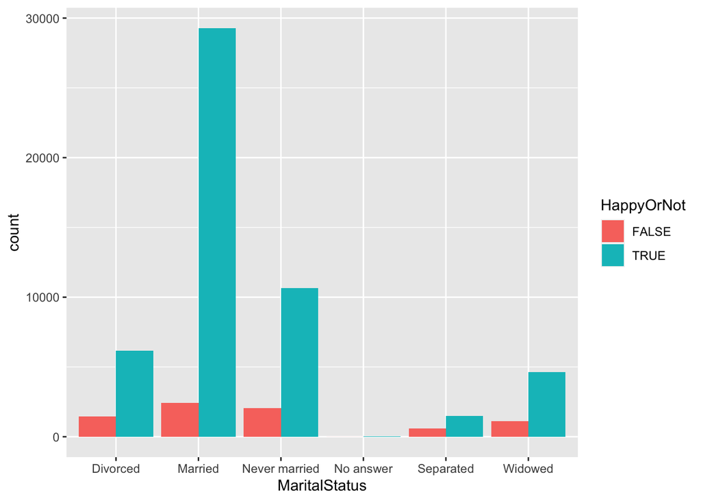

```r
happiness <- dat %>%
  filter(Happiness %in% c('Very happy', 'Pretty happy', 'Not too happy')) %>%
  mutate(HappyOrNot = (Happiness %in% c('Very happy', 'Pretty happy')))

ggplot(data = happiness) + geom_bar(mapping = aes(x = MaritalStatus, fill = HappyOrNot), position = 'dodge')
```

The graph above shows that people are mostly happy despite their marital status. Obviously, “Married” group has the most number of happy people compared to the other groups. “Never married” group follow as the second group that has the most number of happy people, and “Divorced”, “Widowed”, “Separated” follow after that.  
Despite “Married” group has the most number of happy people, the same group also has the most count for not happy numbers. Similar to the number of happy count, “Never married” follow as the close second that has the most count for not happy.

#### Question 4

Does party affiliation affect the relationship you found in the last question

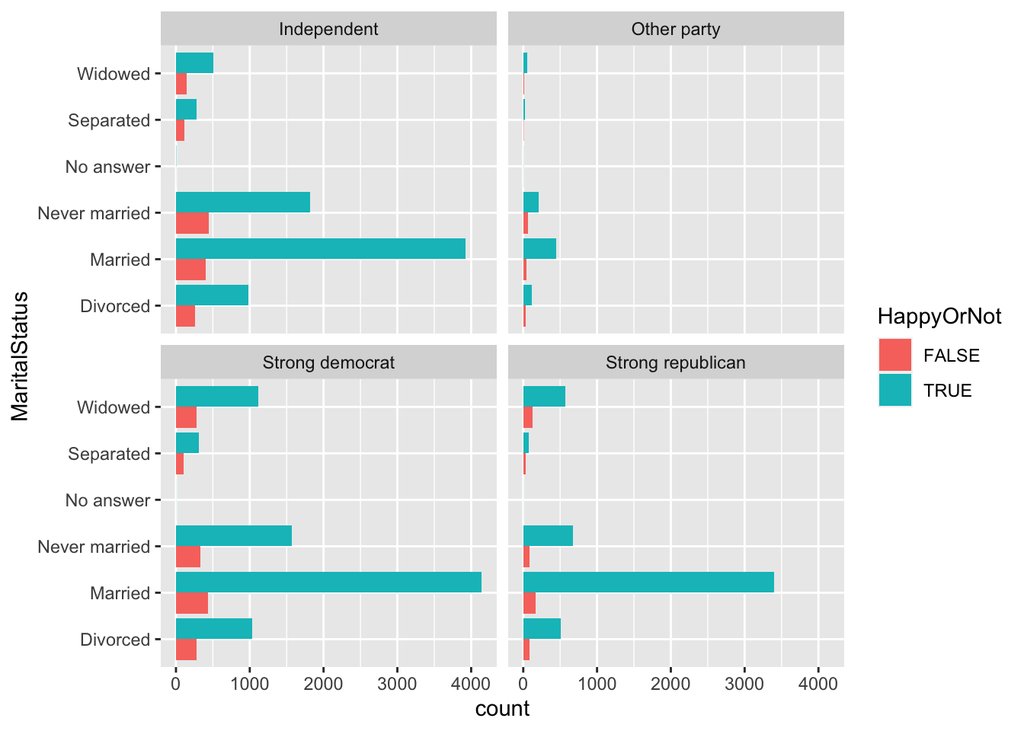

```r
filteredHappiness <- happiness %>% filter(Politics %in% c('Independent', 'Strong democrat', 'Strong republican', 'Other party'))

ggplot(data = filteredHappiness) + geom_bar(mapping = aes(x = MaritalStatus, fill = HappyOrNot), position = 'dodge') + facet_wrap(~Politics) + coord_flip()
```

I don’t think its appropriate to say politic party affiliation affect the relationship. However, looking at each facet (represent party affiliation), every politic party affiliation group (Independent, Other party, Strong democrat, Strong republican) are usually happy when they are married.  
However, the numbers of count are different for each politic party affiliation group. “Strong democrat” has the most number of happy married people compared to the other 3 groups, followed by “Independent”, “Strong republican”, and “Other party” respectively.

#### Question 5

Explore an interesting question (not covered by the previous questions), and answer the question using the GSS data.  
**Question: How Gender and MaritalStatus affecting the Year School Completed**

```r
selectedDat <- dat %>%
  group_by(MaritalStatus, Gender) %>%
  summarize(AvgYearsSchoolCompleted = mean(YearsSchoolCompleted))
```

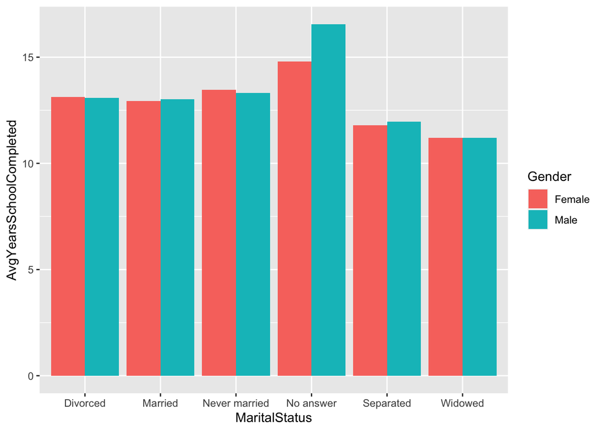

```r
ggplot(selectedDat, aes(x=MaritalStatus, y=AvgYearsSchoolCompleted, fill=Gender)) + geom_bar(stat="identity", position = 'dodge')
```